# Data Product Projects

notebooks-skp 는 St. Kilda Pier 상에서 오픈된 데이터 셋을 이용하여 다양한 데이터 사이언스 프로젝트를 진행할 예정입니다.

SKP 위에서 Data Collection 부터 Data Product 빌드까지 진행해 보면서, 데이터 사이언스 전반의 스킬들을 이해하고 적용하는 역활을 수행할 것입니다.

St. Kilda Pier 는 빅테이더를 위한 Docker 기반 데이터 사이언스 플랫폼 입니다.

전체 소스는 아래 Github 에서 확인할 수 있습니다.

- St.Kilda Pier: https://github.com/comafire/st-kilda-pier
- notebooks-skp: https://github.com/comafire/notebooks-skp

처음으로, MNIST 데이터 셋을 이용하는 가상의 프로젝트를 통한 템플릿 성격의 프로젝트가 올라와 있으며, 다양한 데이터 사이언스 프로젝트들이 추가될 예정입니다.

- mnist: https://github.com/comafire/notebooks-skp/tree/master/mnist

# Directory Structure

notebooks-skp에서 사용하는 프로젝트 템플릿 디렉토리 구조는 아래와 같습니다.

```
.
├── README.ipynb: 프로젝트의 전반적인 정보
├── bin: 프로젝트 수행 스크립트 관련
├── doc: 프로젝트 문서
├── etc: 프로젝트 설정 관련
└── src: 프로젝트 소스
    ├── backend: Backend 서비스 관련, ex) REST API
    └── frontend: Frontend 서비스 관련, ex) Web UI
```

# Data Science Methodology

Data Product를 위한 데이터 사시언스 프로젝트를 진행할때, 구조적으로 진행하기 위해서 각 팀마다 자신의 팀들에게 맞는 프로세스를 정의하고 사용하게 됩니다. 여기서는 KDD 에서 제시하였던 프로세스를 약간 수정해서 사용합니다.

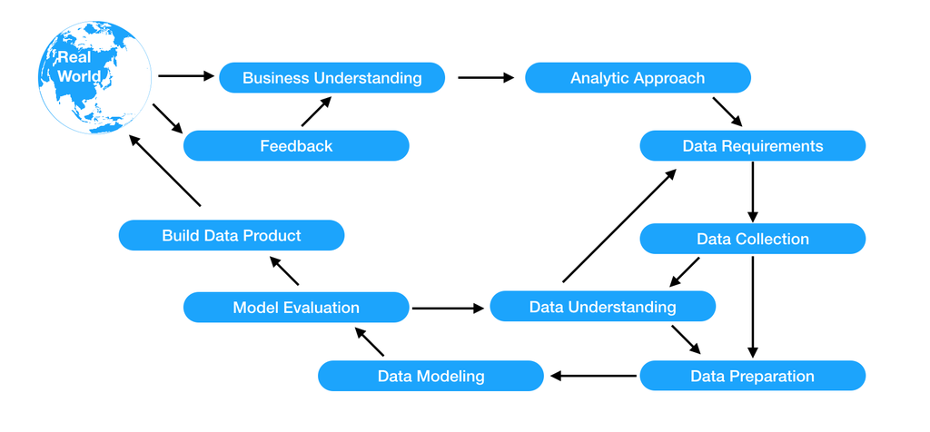

```python
from IPython.display import Image

Image('../galleries/2018-notebooks-skp-001.png', width=1024)
```

- Business Understanding
  - 비지니스의 이해를 통해 풀어야 할 문제에 대한 정의와 프로젝트의 목표 및 결과를 설정.
- Analytic Approach
  - 통계, 머신러닝 기술을 이용하여 프로젝트 결과를 위한 접근방법 정의.
- Data Requirements
  - 데이터 모델링에 사용될 알고리즘에 따라 필요한 데이터의 요구 사항정의.
- Data Collection
  - 데이터 모델링에 사용될 데이터 Raw Data 수집 방법 정의.
- Data Understanding
  - 제공된 데이터에 대한 통계적, 시각적 방법을 통해 초기 데이터를 이해.
- Data Preparation
  - Data Collection 을 통해 수집된 Raw Data 를 각 모델에서 필요한 입력 데이터 형태에 맞게 변형.
- Data Modeling
  - Data Preparation 을 통해 제공된 훈련용 입력 데이터를 이용해 데이터 모델 훈련.
- Model Evaluation
  - Data Modeling 을 통해 훈련된 모델을 이용해 테스트 데이터에 대한 모델 성능을 평가.
- Build Data Product
  - 최종 선택된 데이터 모델을 이용하여 Data Product 을 구축.
- Feedback
  - Data Product 사용자들의 Feedback 을 받아 전체 프로세스를 순환하면서 발전 시킴.